### TEST FOR LINEARITY AND INDEPENDENCE

```python
# Create a dataframe with actual, fitted and residual values
df_pred = pd.DataFrame()

df_pred["Actual Values"] = y_train  # actual values
df_pred["Fitted Values"] = olsmod2.fittedvalues  # predicted values
df_pred["Residuals"] = olsmod2.resid  # residuals

df_pred.head()
```

|  | Actual Values | Fitted Values | Residuals |
| --- | --- | --- | --- |
| 844 | 4.609959 | 4.549595 | 0.060364 |
| 1539 | 4.715638 | 4.764431 | -0.048793 |
| 3452 | 4.735233 | 4.620537 | 0.114696 |
| 1727 | 4.160288 | 4.242511 | -0.082222 |
| 1926 | 4.218772 | 4.172596 | 0.046176 |

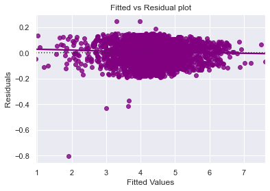

```python
# let's plot the fitted values vs residuals

sns.residplot(
    data=df_pred, x="Fitted Values", y="Residuals", color="purple", lowess=True
)
plt.xlabel("Fitted Values")
plt.ylabel("Residuals")
plt.title("Fitted vs Residual plot")
plt.show()
```

- The scatter plot shows the distribution of residuals (errors) vs fitted values (predicted values).
- If there exist any pattern in this plot, we consider it as signs of non-linearity in the data and a pattern means that the model doesn't capture non-linear effects.
- We see no pattern in the plot above. Hence, the assumptions of linearity and independence are satisfied.

### TEST FOR NORMALITY

#### How to check normality?

- The shape of the histogram of residuals can give an initial idea about the normality.
- It can also be checked via a Q-Q plot of residuals. If the residuals follow a normal distribution, they will make a straight line plot, otherwise not.
- Other tests to check for normality includes the Shapiro-Wilk test.
- Null hypothesis: Residuals are normally distributed
- Alternate hypothesis: Residuals are not normally distributed

### How to fix if this assumption is not followed?

- We can apply transformations like log, exponential, arcsinh, etc. as per our data.

### Let's check the shape of the residual.

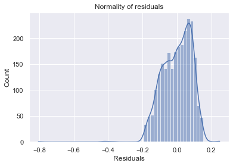

```python
# histogram plot of the residual
sns.histplot(data=df_pred, x="Residuals", kde=True)
plt.title("Normality of residuals")
plt.show()
```

- The histogram of residuals does have a shape close to bell shape.

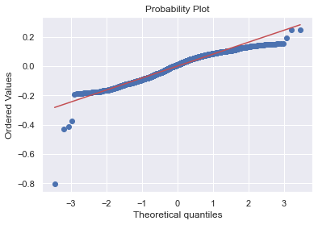

```python
import pylab
import scipy.stats as stats

stats.probplot(df_pred["Residuals"], dist="norm", plot=pylab)
plt.show()
```

- The residuals more or less follow a straight line except for the tails.
- Let's check the results of the Shapiro-Wilk test.

#### Let's use shapiro test for normality

```python
# Shipiro test for normality
stats.shapiro(df_pred["Residuals"])
```

```
ShapiroResult(statistic=0.9563100934028625, pvalue=9.555408204067962e-27)
```

- Since p-value < 0.05, the residuals are not normal as per the Shapiro-Wilk test.
- Strictly speaking, the residuals are not normal.
- However, as an approximation, we can accept this distribution as close to being normal.
- So, the assumption is satisfied.

### TEST FOR HOMOSCEDASTICITY

- Heteroscedascity: If the variance is unequal for the residuals across the regression line, then the data is said to be heteroscedastic.

#### How to check for homoscedasticity?

- The residual vs fitted values plot can be looked at to check for homoscedasticity. In the case of heteroscedasticity, the residuals can form an arrow shape or any other non-symmetrical shape.
- The goldfeldquandt test can also be used. If we get a p-value > 0.05 we can say that the residuals are homoscedastic. Otherwise, they are heteroscedastic.
- Null hypothesis: Residuals are homoscedastic
- Alternate hypothesis: Residuals have heteroscedasticity

### How to fix if this assumption is not followed?

- Heteroscedasticity can be fixed by adding other important features or making transformations.

```python
import statsmodels.stats.api as sms
from statsmodels.compat import lzip

name = ["F statistic", "p-value"]
test = sms.het_goldfeldquandt(df_pred["Residuals"], X_train4)
lzip(name, test)
```

```
[('F statistic', 1.0780199183229537), ('p-value', 0.09280902898661736)]
```

- Since p-value > 0.05, we can say that the residuals are homoscedastic. So, this assumption is satisfied.

## Final Model Summary

#### Automate the linear regresion equation of fit

```python
# Let us write the equation of linear regression
Equation = "Used Phone Price ="
print(Equation, end=" ")
for i in range(len(X_train4.columns)):
    if i == 0:
        print(np.round(olsmod2.params[i], 4), "+", end=" ")
    elif i != len(X_train4.columns) - 1:
        print(
            "(",
            np.round(olsmod2.params[i], 4),
            ")*(",
            X_train4.columns[i],
            ")",
            "+",
            end="  ",
        )
    else:
        print("(", np.round(olsmod2.params[i], 4), ")*(", X_train4.columns[i], ")")
```

```
Used Phone Price = -12.746 + ( 0.0063 )*( release_year ) +  ( -0.0011 )*( days_used ) +  ( 1.0011 )*( new_price_log ) +  ( -0.0373 )*( brand_name_Gionee ) +  ( -0.0108 )*( 4g_yes ) +  ( 0.0242 )*( 5g_yes )
```

#### Now that we have checked all the assumptions of linear regression and they are satisfied, we can move towards the prediction part.

```python
# predictions on the test set
pred = olsmod2.predict(X_test4)

df_pred_test = pd.DataFrame({"Actual": y_test, "Predicted": pred})
df_pred_test.sample(10, random_state=1)
```

|  | Actual | Predicted |
| --- | --- | --- |
| 2098 | 3.418382 | 3.422896 |
| 278 | 5.276430 | 5.280973 |
| 26 | 5.751493 | 5.704627 |
| 2910 | 4.499476 | 4.458647 |
| 2631 | 4.237001 | 4.165908 |
| 1582 | 4.495132 | 4.643285 |
| 2110 | 6.067916 | 5.992102 |
| 3160 | 4.179604 | 4.096506 |
| 2817 | 4.751605 | 4.648188 |
| 549 | 3.670970 | 3.755021 |

- We can observe here that our model has returned pretty good prediction results, and the actual and predicted values are comparable.
- We can also visualize comparison result as a bar graph.

#### Note: As the number of records is large, for representation purpose, we are taking a sample of 25 records only.

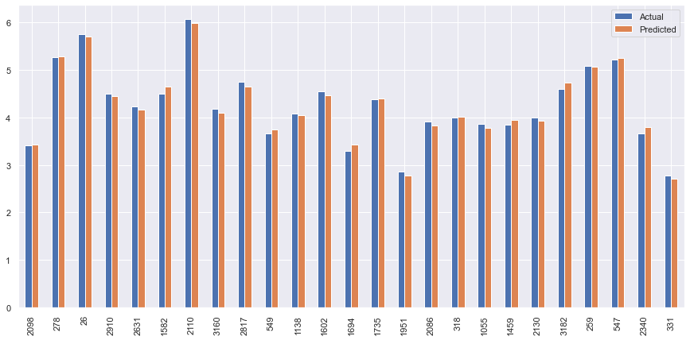

```python
df2 = df_pred_test.sample(25, random_state=1)
df2.plot(kind="bar", figsize=(15, 7))
plt.show()
```

```python
# checking model performance on train set (seen 70% data)
print("Training Performance\n")
olsmod2_train_perf = model_performance_regression(olsmod2, X_train4, y_train)
olsmod2_train_perf
```

```
Training Performance
```

|  | RMSE | MAE | R-squared | Adj. R-squared | MAPE |
| --- | --- | --- | --- | --- | --- |
| 0 | 0.08348 | 0.069271 | 0.990093 | 0.990066 | 1.713701 |

```python
# checking model performance on test set (seen 30% data)
print("Test Performance\n")
olsmod2_test_perf = model_performance_regression(olsmod2, X_test4, y_test)
olsmod2_test_perf
```

```
Test Performance
```

|  | RMSE | MAE | R-squared | Adj. R-squared | MAPE |
| --- | --- | --- | --- | --- | --- |
| 0 | 0.081662 | 0.070057 | 0.989982 | 0.989916 | 1.695014 |

#### Observations

- The model is able to explain ~99% of the variation in the data, which is very good.
- The train and test RMSE and MAE are low and comparable. So, our model is not suffering from overfitting.
- The MAPE on the test set suggests we can predict within ~1.7% of the used_price.
- Hence, we can conclude the model olsmod2 is good for prediction as well as inference purposes.

### Let's recreate the final statsmodels model and print it's summary to gain insights.

```python
olsmodel_final = sm.OLS(y_train, X_train4).fit()
print(olsmodel_final.summary())
```

```
                            OLS Regression Results
==============================================================================
Dep. Variable:         used_price_log   R-squared:                       0.990
Model:                            OLS   Adj. R-squared:                  0.990
Method:                 Least Squares   F-statistic:                 4.151e+04
Date:                Tue, 28 Sep 2021   Prob (F-statistic):               0.00
Time:                        13:38:19   Log-Likelihood:                 2659.5
No. Observations:                2499   AIC:                            -5305.
Df Residuals:                    2492   BIC:                            -5264.
Df Model:                           6
Covariance Type:            nonrobust
=====================================================================================
                        coef    std err          t      P>|t|      [0.025      0.975]
-------------------------------------------------------------------------------------
const               -12.7460      2.652     -4.806      0.000     -17.946      -7.546
release_year          0.0063      0.001      4.766      0.000       0.004       0.009
days_used            -0.0011   1.04e-05   -106.504      0.000      -0.001      -0.001
new_price_log         1.0011      0.003    366.766      0.000       0.996       1.006
brand_name_Gionee    -0.0373      0.014     -2.721      0.007      -0.064      -0.010
4g_yes               -0.0108      0.005     -2.211      0.027      -0.020      -0.001
5g_yes                0.0242      0.009      2.564      0.010       0.006       0.043
==============================================================================
Omnibus:                      361.730   Durbin-Watson:                   2.022
Prob(Omnibus):                  0.000   Jarque-Bera (JB):             1175.472
Skew:                          -0.725   Prob(JB):                    5.62e-256
Kurtosis:                       6.031   Cond. No.                     3.37e+06
==============================================================================

Notes:
[1] Standard Errors assume that the covariance matrix of the errors is correctly specified.
[2] The condition number is large, 3.37e+06. This might indicate that there are
strong multicollinearity or other numerical problems.
```

### Recommendations

- The model can be used to predict the price of used phone
- Phones with 5g network have high used/resale price and should be focused on with les 4g phones.
- Gionee phones do not have a good used/resale pice. Investment in such phones should be reduced.
- Phones that has been used for long period have poor used/resale price. Investment in such phones is discouraged.
- Recently released phones should also be focused on as they have a high resale price.